# Proj.SL_Final_CKS_v02

## Project Solution - Supervised Learning:

## Contents:

Data Description

Attribute Information

Objective

Steps, Tasks and Solution

## Data Description

The data include customer demographic information (age, income, etc.), the customer's relationship with the bank (mortgage, securities account, etc.), and the customer response to the last personal loan campaign (Personal Loan).

## Attribute Information

 ID : Customer ID

 Age : Customer's age in completed years

 Experience : years of professional experience

 Income : Annual income of the customer (in $)

 ZIP Code : Home Address ZIP code

 Family : Family size of the customer

 CCAvg : Avg. spending on credit cards per month (in $)

 Education : Education Level

1. Undergrad
2. Graduate
3. Advanced/Professional  Mortgage : Value of house mortgage if any (in $)

 Personal Loan : Did this customer accept the personal loan offered in the last campaign?

 Securities Account : Does the customer have a securities account with the bank?

 CD Account : Does the customer have a certificate of deposit (CD) account with the bank?

 Online : Does the customer use internet banking facilities?

 Credit card : Does the customer use a credit card issued by Bank? </font>

## Objective

The classification goal is to predict the likelihood of a liability customer buying personal loans.

## Steps, Tasks and Solutions

1. Import the necessary libraries
1. Read the data as a data frame and study the data distribution on each attribute, EDA
1. EDA & Target column distribution Analysis
1. Split the data into training and test set
1. Building of different classification models
   - a. Classification model - Logistic
   - b. Classification model - Naïve Bayes
   - c. Classification model - K-NN

     5.a.1. Classification model - Logistic - Confusion Matrix

     5.a.2. Classification Report - Logistic

     5.b.1. Classification model - Naïve Bayes - Confusion Matrix

     5.b.2. Classification Report - Naïve Bayes

     5.c.1. Classification model - K-NN - Confusion Matrix

     5.c.2. Classification Report - K-NN
1. Comments
1. Use of Minmax Scalar and VIF to reevaluate the model
1. Comments after use of VIF and minmax scalar
1. Optional - SVM </font>

## 1. Import the necessary libraries

```python
# importing the necessary package for performing advanced mathematical operation
import numpy as np

# importing the necessary package for storing & managing data
import pandas as pd

# importing the necessary packages for visualisation

import seaborn as sns
import matplotlib.pyplot as plt

sns.set (color_codes = True) # for adding nice background to the graphs

# commmand to tell Python to display my graphs
%matplotlib inline

# for doing statistical calculation
import scipy.stats as stats

import scipy


from sklearn.model_selection import train_test_split
from sklearn import linear_model
import statsmodels.api as sm
from sklearn import metrics
from sklearn import datasets

import warnings
warnings.filterwarnings('ignore')

# Here the effort has been made to import all the libraries or packages which are to be used in subsequent operations.
# other important packages will be imported as and when required and based upon that operation shall be carried outS
```

## 2. Read the data as a data frame and study the data distribution on each attribute, EDA

```python
df = pd.read_csv('Bank_Personal_Loan_Modelling.csv')
```

#### - Data is being imported by using pd.read_csv() method, which is a very simple, fast and widely used method for loading the data.

```python
df.shape # checking the shape of data frame
```

```
(5000, 14)
```

#### - The above method is used to check the shape of the dataset.

#### - There are basically 5000 rows and 14 columns present inside the dataset

```python
df.head() # This function shows the first 5 rows of the dataset
```

|  | ID | Age | Experience | Income | ZIP Code | Family | CCAvg | Education | Mortgage | Personal Loan | Securities Account | CD Account | Online | CreditCard |
| --- | --- | --- | --- | --- | --- | --- | --- | --- | --- | --- | --- | --- | --- | --- |
| 0 | 1 | 25 | 1 | 49 | 91107 | 4 | 1.6 | 1 | 0 | 0 | 1 | 0 | 0 | 0 |
| 1 | 2 | 45 | 19 | 34 | 90089 | 3 | 1.5 | 1 | 0 | 0 | 1 | 0 | 0 | 0 |
| 2 | 3 | 39 | 15 | 11 | 94720 | 1 | 1.0 | 1 | 0 | 0 | 0 | 0 | 0 | 0 |
| 3 | 4 | 35 | 9 | 100 | 94112 | 1 | 2.7 | 2 | 0 | 0 | 0 | 0 | 0 | 0 |
| 4 | 5 | 35 | 8 | 45 | 91330 | 4 | 1.0 | 2 | 0 | 0 | 0 | 0 | 0 | 1 |

```python
df.tail() # This function shows the bottom 5 rows of the dataset
```

|  | ID | Age | Experience | Income | ZIP Code | Family | CCAvg | Education | Mortgage | Personal Loan | Securities Account | CD Account | Online | CreditCard |
| --- | --- | --- | --- | --- | --- | --- | --- | --- | --- | --- | --- | --- | --- | --- |
| 4995 | 4996 | 29 | 3 | 40 | 92697 | 1 | 1.9 | 3 | 0 | 0 | 0 | 0 | 1 | 0 |
| 4996 | 4997 | 30 | 4 | 15 | 92037 | 4 | 0.4 | 1 | 85 | 0 | 0 | 0 | 1 | 0 |
| 4997 | 4998 | 63 | 39 | 24 | 93023 | 2 | 0.3 | 3 | 0 | 0 | 0 | 0 | 0 | 0 |
| 4998 | 4999 | 65 | 40 | 49 | 90034 | 3 | 0.5 | 2 | 0 | 0 | 0 | 0 | 1 | 0 |
| 4999 | 5000 | 28 | 4 | 83 | 92612 | 3 | 0.8 | 1 | 0 | 0 | 0 | 0 | 1 | 1 |

```python
df.columns
# it's better to have a look at all the columns available in the dataset
```

```
Index(['ID', 'Age', 'Experience', 'Income', 'ZIP Code', 'Family', 'CCAvg',
       'Education', 'Mortgage', 'Personal Loan', 'Securities Account',
       'CD Account', 'Online', 'CreditCard'],
      dtype='object')
```

```python
df.info()
# This function gives the information of the dataset like data type, memory usage etc..
```

```
<class 'pandas.core.frame.DataFrame'>
RangeIndex: 5000 entries, 0 to 4999
Data columns (total 14 columns):
 #   Column              Non-Null Count  Dtype
---  ------              --------------  -----
 0   ID                  5000 non-null   int64
 1   Age                 5000 non-null   int64
 2   Experience          5000 non-null   int64
 3   Income              5000 non-null   int64
 4   ZIP Code            5000 non-null   int64
 5   Family              5000 non-null   int64
 6   CCAvg               5000 non-null   float64
 7   Education           5000 non-null   int64
 8   Mortgage            5000 non-null   int64
 9   Personal Loan       5000 non-null   int64
 10  Securities Account  5000 non-null   int64
 11  CD Account          5000 non-null   int64
 12  Online              5000 non-null   int64
 13  CreditCard          5000 non-null   int64
dtypes: float64(1), int64(13)
memory usage: 547.0 KB
```

#### - There are basically 5000 rows and 14 columns present in the dataset, out of which one is target/dependent column and rest all are independent columns.

#### - Out of 14 columns, CCAvg is the only column which is float data type in nature and rest of the columns are integer in nature

#### - Categorical Columns: Family, Education, Personal Loan, Securities Account, CD Account, CD Account, Online, CreditCard

#### - Non Categorical columns: Except above 8 categorical columns, all others

```python
# Name of the columns contain gap in between two words, in order to avoid any kind of error while proceeding ahead, the names of the columns can be renamed
df=df.rename(columns = {'Personal Loan':'PL', 'Securities Account':'Securities_Account', 'CD Account':'CD_Account'})
```

```python
df.columns
```

```
Index(['ID', 'Age', 'Experience', 'Income', 'ZIP Code', 'Family', 'CCAvg',
       'Education', 'Mortgage', 'PL', 'Securities_Account', 'CD_Account',
       'Online', 'CreditCard'],
      dtype='object')
```

### Checking the distribution and frequency tabel for the categorical columns

```python
# checking the value of counts for Family
pd.value_counts(df['Family'])
```

```
1    1472
2    1296
4    1222
3    1010
Name: Family, dtype: int64
```

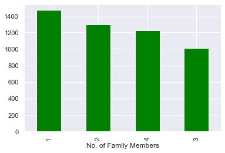

```python
pd.value_counts(df['Family']).plot(kind = 'bar', color = 'green');
plt.xlabel('No. of Family Members');
```

```python
# checking the value of counts for Education
pd.value_counts(df['Education'])
```

```
1    2096
3    1501
2    1403
Name: Education, dtype: int64
```

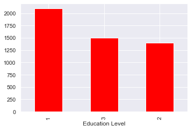

```python
pd.value_counts(df['Education']).plot(kind = 'bar', color = 'red');
plt.xlabel('Education Level');
```

```python
# checking the value of counts for Personal Loan
pd.value_counts(df['PL'])
```

```
0    4520
1     480
Name: PL, dtype: int64
```

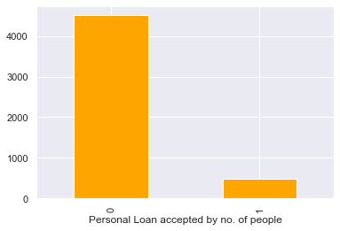

```python
pd.value_counts(df['PL']).plot(kind = 'bar', color = 'orange');
plt.xlabel('Personal Loan accepted by no. of people');
```

```python
# checking the value of counts for Securities Account
pd.value_counts(df['Securities_Account'])
```

```
0    4478
1     522
Name: Securities_Account, dtype: int64
```

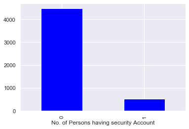

```python
pd.value_counts(df['Securities_Account']).plot(kind = 'bar', color = 'blue');
plt.xlabel('No. of Persons having security Account');
```

```python
# checking the value of counts for CD Account
pd.value_counts(df['CD_Account'])
```

```
0    4698
1     302
Name: CD_Account, dtype: int64
```

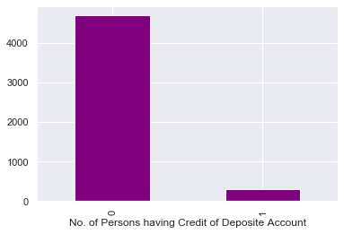

```python
pd.value_counts(df['CD_Account']).plot(kind = 'bar', color = 'purple');
plt.xlabel('No. of Persons having Credit of Deposite Account');
```

```python
# checking the value of counts for Online
pd.value_counts(df['Online'])
```

```
1    2984
0    2016
Name: Online, dtype: int64
```

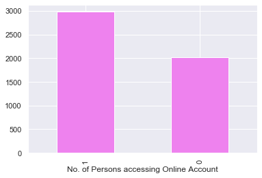

```python
pd.value_counts(df['Online']).plot(kind = 'bar', color = 'violet');
plt.xlabel('No. of Persons accessing Online Account');
```

```python
# checking the value of counts for CreditCard
pd.value_counts(df['CreditCard'])
```

```
0    3530
1    1470
Name: CreditCard, dtype: int64
```

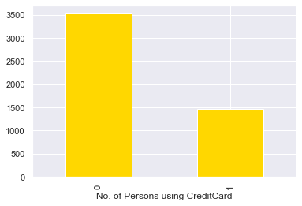

```python
pd.value_counts(df['CreditCard']).plot(kind = 'bar', color = 'gold');
plt.xlabel('No. of Persons using CreditCard');
```

```python
df.isna().apply(pd.value_counts) # null value check
```

|  | ID | Age | Experience | Income | ZIP Code | Family | CCAvg | Education | Mortgage | PL | Securities_Account | CD_Account | Online | CreditCard |
| --- | --- | --- | --- | --- | --- | --- | --- | --- | --- | --- | --- | --- | --- | --- |
| False | 5000 | 5000 | 5000 | 5000 | 5000 | 5000 | 5000 | 5000 | 5000 | 5000 | 5000 | 5000 | 5000 | 5000 |

#### - There are no Null values in any one of the columns

Using the below code we are going to test whether this data frame consists of categorical variables with values as “?”.

```python
for value in ['Family','Education','PL','Securities_Account','CD_Account','Online','CreditCard']:
    print(value,":", sum(df[value] == '?'))
```

```
Family : 0
Education : 0
PL : 0
Securities_Account : 0
CD_Account : 0
Online : 0
CreditCard : 0
```

#### - No such values are present in this data set..

#### - So, it can be treated as a clean dataset on which we can perform the further course of action.

```python
df.describe().transpose()
```

|  | count | mean | std | min | 25% | 50% | 75% | max |
| --- | --- | --- | --- | --- | --- | --- | --- | --- |
| ID | 5000.0 | 2500.500000 | 1443.520003 | 1.0 | 1250.75 | 2500.5 | 3750.25 | 5000.0 |
| Age | 5000.0 | 45.338400 | 11.463166 | 23.0 | 35.00 | 45.0 | 55.00 | 67.0 |
| Experience | 5000.0 | 20.104600 | 11.467954 | -3.0 | 10.00 | 20.0 | 30.00 | 43.0 |
| Income | 5000.0 | 73.774200 | 46.033729 | 8.0 | 39.00 | 64.0 | 98.00 | 224.0 |
| ZIP Code | 5000.0 | 93152.503000 | 2121.852197 | 9307.0 | 91911.00 | 93437.0 | 94608.00 | 96651.0 |
| Family | 5000.0 | 2.396400 | 1.147663 | 1.0 | 1.00 | 2.0 | 3.00 | 4.0 |
| CCAvg | 5000.0 | 1.937938 | 1.747659 | 0.0 | 0.70 | 1.5 | 2.50 | 10.0 |
| Education | 5000.0 | 1.881000 | 0.839869 | 1.0 | 1.00 | 2.0 | 3.00 | 3.0 |
| Mortgage | 5000.0 | 56.498800 | 101.713802 | 0.0 | 0.00 | 0.0 | 101.00 | 635.0 |
| PL | 5000.0 | 0.096000 | 0.294621 | 0.0 | 0.00 | 0.0 | 0.00 | 1.0 |
| Securities_Account | 5000.0 | 0.104400 | 0.305809 | 0.0 | 0.00 | 0.0 | 0.00 | 1.0 |
| CD_Account | 5000.0 | 0.060400 | 0.238250 | 0.0 | 0.00 | 0.0 | 0.00 | 1.0 |
| Online | 5000.0 | 0.596800 | 0.490589 | 0.0 | 0.00 | 1.0 | 1.00 | 1.0 |
| CreditCard | 5000.0 | 0.294000 | 0.455637 | 0.0 | 0.00 | 0.0 | 1.00 | 1.0 |

### Comments:

#### - Average spending on credit cards seems to be very less among all the customers. Avg. Credit card spending of 75% of customers is around 2.50k dollar.

#### - Overall most of the customers are having a good educational background, and it can be assumed above 50% customers are having graduation.

#### - Mortgage column seems to be quite different as the median value of this is 0 and it seems to be highly right skewed.

#### - Rest of the columns are categorical in nature and can be interpreted by using histogram plot..

```python
np.sum((df['Experience'] < 0).values)
```

```
52
```

#### - There are basically 52 numbers of negative values present in the data frame for Experience column, therefore, it is not advisable to drop those many numbers of columns, which can affect our model accuracy adversely, hence, we can convert those negative values to positive values indeed

```python
df1 = abs(df)
# here we're converting all negative values to positive values present in the data frame..., and stored the same in a new dataframe all together.
```

```python
np.sum((df1['Experience'] < 0).values)
```

```
0
```

#### - Thus, all negative values have been converted into positive values

```python
df1['Experience'].describe().T
```

```
count    5000.000000
mean       20.134600
std        11.415189
min         0.000000
25%        10.000000
50%        20.000000
75%        30.000000
max        43.000000
Name: Experience, dtype: float64
```

#### - Hence, the dataframe seems to be legit to draw further inference..

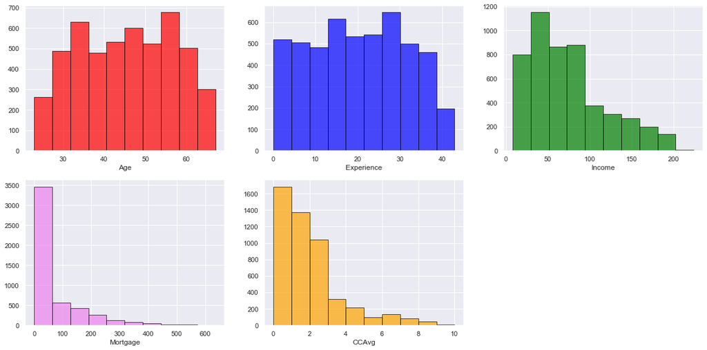

```python
# Plotting the distribution of continuous features individually

plt.figure(figsize= (20,15))
plt.subplot(3,3,1)
plt.hist(df1.Age, color='red', edgecolor = 'black', alpha = 0.7)
plt.xlabel('Age')

plt.subplot(3,3,2)
plt.hist(df1.Experience, color='blue', edgecolor = 'black', alpha = 0.7)
plt.xlabel('Experience')

plt.subplot(3,3,3)
plt.hist(df1.Income, color='green', edgecolor = 'black', alpha = 0.7)
plt.xlabel('Income')

plt.subplot(3,3,4)
plt.hist(df1.Mortgage, color='violet', edgecolor = 'black', alpha = 0.7)
plt.xlabel('Mortgage')

plt.subplot(3,3,5)
plt.hist(df1.CCAvg, color='orange', edgecolor = 'black', alpha = 0.7)
plt.xlabel('CCAvg')

plt.show()
```

### Comments:

#### - Age and Experience look like multimodal in nature and seem to be uniformly distributed

#### - Income seems to be a bit right skewed

#### - And the columns Mortgage and CCAvg are highly right skewed..

#### - To confirm the skewness of the above independent variables we can measure the Skewness value..

```python
Skewness = pd.DataFrame({'Skewness' : [stats.skew(df1.Age),stats.skew(df1.Experience),stats.skew(df1.Income),stats.skew(df1.Mortgage),stats.skew(df1.CCAvg)]},
                        index=['Age','Experience','Income', 'Mortgage','CCAvg'])  # Measure the skeweness of the required columns
Skewness
```

|  | Skewness |
| --- | --- |
| Age | -0.029332 |
| Experience | -0.010035 |
| Income | 0.841086 |
| Mortgage | 2.103371 |
| CCAvg | 1.597964 |

### Comments:

#### - And the Mortgage and CCAvg are highly right or positive skewed because of a huge positive difference between Mean and Median. Thus the skewness in these variable may lead to heteroscedasticity, and may affect the accuracy of model.

### * Now to check the presence of outliers, box plot can be drawn for independent continous variables

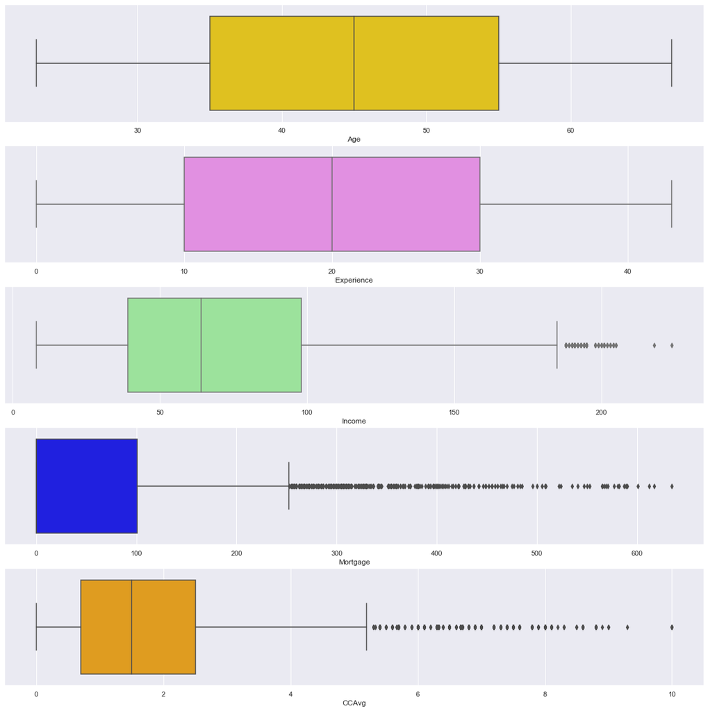

```python
plt.figure(figsize= (20,20))
plt.subplot(5,1,1)
sns.boxplot(x= df1.Age,  color='gold')

plt.subplot(5,1,2)
sns.boxplot(x= df1.Experience, color='violet')

plt.subplot(5,1,3)
sns.boxplot(x= df1.Income, color='lightgreen')

plt.subplot(5,1,4)
sns.boxplot(x= df1.Mortgage,color='blue')

plt.subplot(5,1,5)
sns.boxplot(x= df1.CCAvg,  color='orange')

plt.show()
```

### Comments:

#### - Income has few outliers or extreme values

#### - Since, Mortgage is highly right skewed, so there are lot of extreme values or outliers present in it.

#### - Similarly, the case is for CCAvg, since it is highly right skewed, a lot of extreme values or outliers presence can be observed.

#### - The outliers present in the data set may also lead to heteroscedasticity.

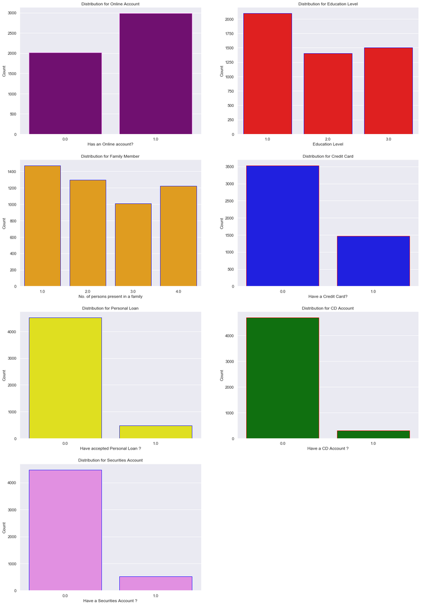

```python
plt.figure(figsize=(20,30))

plt.subplot(4,2,1)
sns.countplot(df1['Online'],label="Count", color = 'purple', edgecolor = 'violet');
plt.xlabel('Has an Online account?')
plt.ylabel('Count')
plt.title('Distribution for Online Account')

plt.subplot(4,2,2)
sns.countplot(df1['Education'],label="Count", color = 'red', edgecolor = 'blue')
plt.xlabel('Education Level')
plt.ylabel('Count')
plt.title('Distribution for Education Level')

plt.subplot(4,2,3)
sns.countplot(df1['Family'],label="Count", color = 'orange', edgecolor = 'blue')
plt.xlabel('No. of persons present in a family')
plt.ylabel('Count')
plt.title('Distribution for Family Member')

plt.subplot(4,2,4)
sns.countplot(df1['CreditCard'],label="Count", color = 'blue', edgecolor = 'red')
plt.xlabel('Have a Credit Card?')
plt.ylabel('Count')
plt.title('Distribution for Credit Card')

plt.subplot(4,2,5)
sns.countplot(df1['PL'],label="Count", color = 'yellow', edgecolor = 'blue')
plt.xlabel('Have accepted Personal Loan ?')
plt.ylabel('Count')
plt.title('Distribution for Personal Loan')

plt.subplot(4,2,6)
sns.countplot(df1['CD_Account'],label="Count", color = 'green', edgecolor = 'red')
plt.xlabel('Have a CD Account ?')
plt.ylabel('Count')
plt.title('Distribution for CD Account')

plt.subplot(4,2,7)
sns.countplot(df1['Securities_Account'],label="Count", color = 'violet', edgecolor = 'blue')
plt.xlabel('Have a Securities Account ?')
plt.ylabel('Count')
plt.title('Distribution for Securities Account');
```

### Comments:

#### - There are a lot more non credit card users than credit users.

#### - Similarly, a lot more individuals have denied for personal loan in the last campaign

#### - The statement repeats its sense for the distribution of CD account and security account, that is most of the individuals are not having CD account and security account

### * Bi-variate distribution of every possible attribute pair

```python
df2 = df1.drop(['ID','ZIP Code'], axis = 1)
df2.columns
```

```
Index(['Age', 'Experience', 'Income', 'Family', 'CCAvg', 'Education',
       'Mortgage', 'PL', 'Securities_Account', 'CD_Account', 'Online',
       'CreditCard'],
      dtype='object')
```

#### - Here I assumed that, the independent columns ID and ZIP code have no role to play in the current dataset to calculate the accuracy of models, thus I dropped off those two..

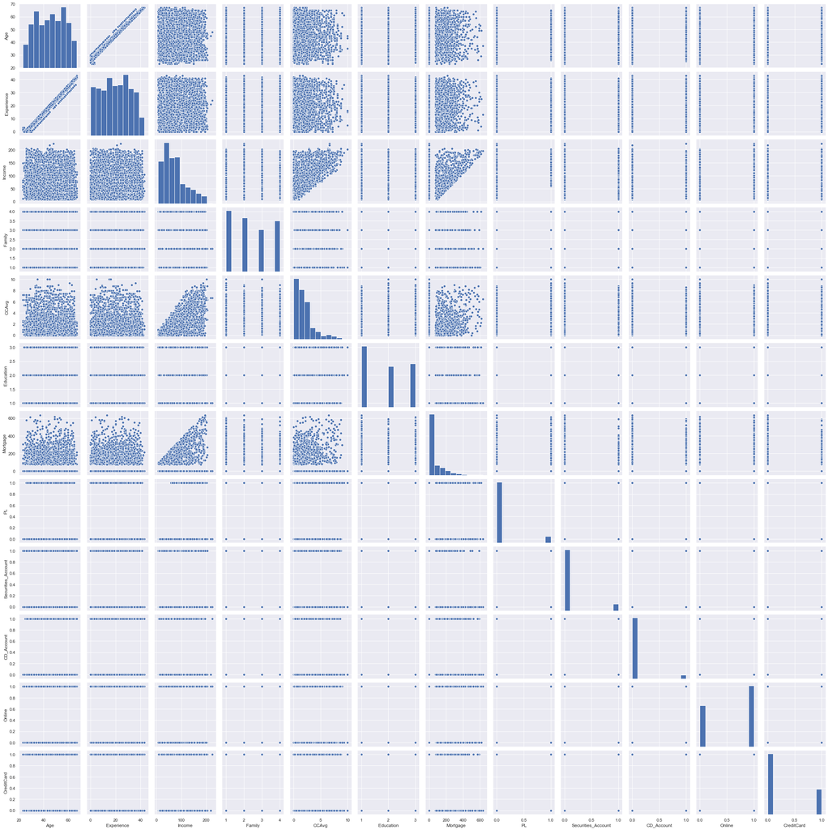

```python
sns.pairplot(df2);
```

```python
df2.corr()
```

|  | Age | Experience | Income | Family | CCAvg | Education | Mortgage | PL | Securities_Account | CD_Account | Online | CreditCard |
| --- | --- | --- | --- | --- | --- | --- | --- | --- | --- | --- | --- | --- |
| Age | 1.000000 | 0.993991 | -0.055269 | -0.046418 | -0.052012 | 0.041334 | -0.012539 | -0.007726 | -0.000436 | 0.008043 | 0.013702 | 0.007681 |
| Experience | 0.993991 | 1.000000 | -0.046876 | -0.051851 | -0.049738 | 0.013919 | -0.011097 | -0.008304 | -0.000989 | 0.009735 | 0.014051 | 0.008851 |
| Income | -0.055269 | -0.046876 | 1.000000 | -0.157501 | 0.645984 | -0.187524 | 0.206806 | 0.502462 | -0.002616 | 0.169738 | 0.014206 | -0.002385 |
| Family | -0.046418 | -0.051851 | -0.157501 | 1.000000 | -0.109275 | 0.064929 | -0.020445 | 0.061367 | 0.019994 | 0.014110 | 0.010354 | 0.011588 |
| CCAvg | -0.052012 | -0.049738 | 0.645984 | -0.109275 | 1.000000 | -0.136124 | 0.109905 | 0.366889 | 0.015086 | 0.136534 | -0.003611 | -0.006689 |
| Education | 0.041334 | 0.013919 | -0.187524 | 0.064929 | -0.136124 | 1.000000 | -0.033327 | 0.136722 | -0.010812 | 0.013934 | -0.015004 | -0.011014 |
| Mortgage | -0.012539 | -0.011097 | 0.206806 | -0.020445 | 0.109905 | -0.033327 | 1.000000 | 0.142095 | -0.005411 | 0.089311 | -0.005995 | -0.007231 |
| PL | -0.007726 | -0.008304 | 0.502462 | 0.061367 | 0.366889 | 0.136722 | 0.142095 | 1.000000 | 0.021954 | 0.316355 | 0.006278 | 0.002802 |
| Securities_Account | -0.000436 | -0.000989 | -0.002616 | 0.019994 | 0.015086 | -0.010812 | -0.005411 | 0.021954 | 1.000000 | 0.317034 | 0.012627 | -0.015028 |
| CD_Account | 0.008043 | 0.009735 | 0.169738 | 0.014110 | 0.136534 | 0.013934 | 0.089311 | 0.316355 | 0.317034 | 1.000000 | 0.175880 | 0.278644 |
| Online | 0.013702 | 0.014051 | 0.014206 | 0.010354 | -0.003611 | -0.015004 | -0.005995 | 0.006278 | 0.012627 | 0.175880 | 1.000000 | 0.004210 |
| CreditCard | 0.007681 | 0.008851 | -0.002385 | 0.011588 | -0.006689 | -0.011014 | -0.007231 | 0.002802 | -0.015028 | 0.278644 | 0.004210 | 1.000000 |

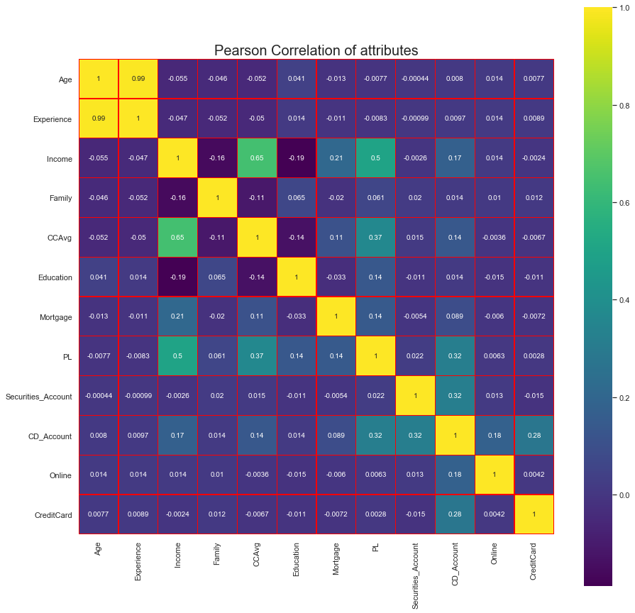

```python
colormap = plt.cm.viridis # Color range to be used in heatmap
plt.figure(figsize=(15,15))
plt.title('Pearson Correlation of attributes', y=1, size=20)
sns.heatmap(df2.corr(),linewidths=0.2,vmax=1.0,
            square=True, cmap=colormap, linecolor='red', annot=True);
```

### Comments:

#### - The columns experience and Age are highly correlated to each other and the value is almost near to 1. It means a perfect collinearity exists between these two independent variables, which is very rare in practice. Thus while calculating any one of these two independent variables can be dropped off.

#### - This is dropping of any one column can help to make the model simpler and avoid overfitting of the model. By which, we can get almost same accuracy in both training and testing sets.

#### - By using the Principle of Parsimony, the model can be made simpler (Occam's Razor) while capturing the collective effort of other independent variables on target variable

## 3. EDA & Target column distribution Analysis

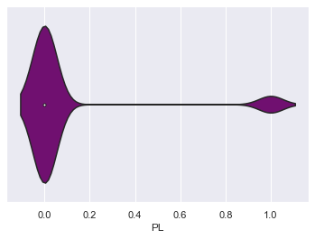

```python
sns.violinplot(df2['PL'], color = 'purple');
```

#### - The above violin plot, shows the vertical mirror image of the distribution and it can be understood that, the number of customers denied for loan is far more than the count of customers accepted the loan.

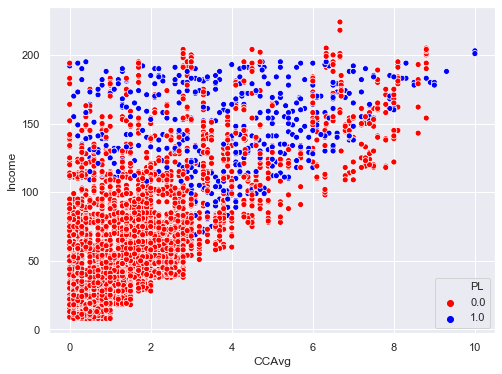

```python
plt.figure(figsize = (8,6))
sns.scatterplot(df2.CCAvg, df2.Income, hue = df2.PL, palette = ['red', 'blue'])
plt.show()
```

### Comments:

#### - It can be understood from the above plot that, customers whose income is more than average and has a good average spending through credit cards were more likely opted for the loan offered to them, thus both CCAvg and Income have a good correlation between them and decides the sentiment of customers for opting the loan

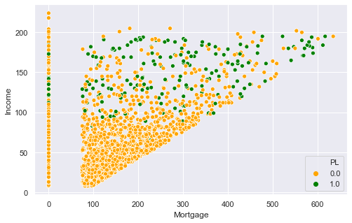

```python
plt.figure(figsize = (8,5))
sns.scatterplot(df2.Mortgage, df2.Income, hue = df2.PL, palette = ['orange', 'green'])
plt.show()
```

### Comments:

#### - From the above scatter plot, it can be interpreted that, a group of customers do not have any mortgage in their name, and this group generally consists of low income customers to high income customers. Interestingly, a few number of customers who do not have any Mortgage registered in their name have accepted the loan offer in last campaign.

#### - Again, the rest of the customer’s income is lightly correlated to the Mortgage. However, The customers who accepted the loan offer can be categorised in high income group and also have mortgage registered in their name.

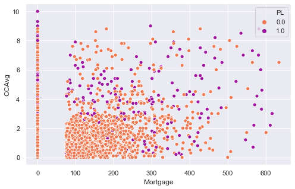

```python
plt.figure(figsize = (8,5))

sns.scatterplot(df2['Mortgage'], df2['CCAvg'], hue=df2['PL'], palette='plasma_r') ;
```

### Comments:

#### - There is no clear-cut correlation between the Credit card Average expenses and Mortgage columns, however, a group of people who do not have mortgage are quit open towards spending on Credit card, and the a few of them also accepted the loan offered in the last campaign.

#### - The rest of the customers who opted for loan are distributed randomly across the feature space..

```python
n_true = len(df2.loc[df2['PL'] == True])
n_false = len(df2.loc[df2['PL'] == False])
print("Number of Persons having Loan: {0} ({1:2.2f}%)".format(n_true, (n_true / (n_true + n_false)) * 100 ))
print("Number of Persons not having Loan: {0} ({1:2.2f}%)".format(n_false, (n_false / (n_true + n_false)) * 100))
```

```
Number of Persons having Loan: 480 (9.60%)
Number of Persons not having Loan: 4520 (90.40%)
```

#### - 90.40% customers have not accepted the loan, however 9.60% of customers accepted the loan offered to them..

## 4. Split the data into training and test set

### * Spliting of data into training & testing data set - 70:30 respectively.

```python
from sklearn.model_selection import train_test_split

X = df2.drop('PL', axis =1) # predictor feature columns (8 x m)
y = df2['PL'] # target / predicted class (1 = true, 0 = false) (1 x m)

x_train, x_test, y_train, y_test = train_test_split(X, y, test_size = 0.3, random_state = 1)

x_train.head()
```

|  | Age | Experience | Income | Family | CCAvg | Education | Mortgage | Securities_Account | CD_Account | Online | CreditCard |
| --- | --- | --- | --- | --- | --- | --- | --- | --- | --- | --- | --- |
| 1334 | 47.0 | 22.0 | 35.0 | 2.0 | 1.3 | 1.0 | 0.0 | 0.0 | 0.0 | 1.0 | 0.0 |
| 4768 | 38.0 | 14.0 | 39.0 | 1.0 | 2.0 | 2.0 | 0.0 | 0.0 | 0.0 | 1.0 | 0.0 |
| 65 | 59.0 | 35.0 | 131.0 | 1.0 | 3.8 | 1.0 | 0.0 | 0.0 | 0.0 | 1.0 | 1.0 |
| 177 | 29.0 | 3.0 | 65.0 | 4.0 | 1.8 | 2.0 | 244.0 | 0.0 | 0.0 | 0.0 | 0.0 |
| 4489 | 39.0 | 13.0 | 21.0 | 3.0 | 0.2 | 2.0 | 0.0 | 0.0 | 0.0 | 1.0 | 0.0 |

```python
# checking the split of data
print('{0:0.2f}% data is in training set'.format((len(x_train)/len(df2.index))*100))
print('{0:0.2f}% data is in testing set'.format((len(x_test)/len(df2.index))*100))
```

```
70.00% data is in training set
30.00% data is in testing set
```

```python
print("Originally customers accepted personal loan    : {0} ({1:0.2f}%)".format(len(df2.loc[df2['PL'] == 1]), (len(df2.loc[df2['PL'] == 1])/len(df2.index)) * 100))
print("Originally customers rejected personal loan   : {0} ({1:0.2f}%)".format(len(df2.loc[df2['PL'] == 0]), (len(df2.loc[df2['PL'] == 0])/len(df2.index)) * 100))
print("")
print("In Training set customers accepted personal loan  : {0} ({1:0.2f}%)".format(len(y_train[y_train[:] == 1]), (len(y_train[y_train[:] == 1])/len(y_train)) * 100))
print("In Training set customers rejected personal loan : {0} ({1:0.2f}%)".format(len(y_train[y_train[:] == 0]), (len(y_train[y_train[:] == 0])/len(y_train)) * 100))
print("")
print("In Testing set customers accepted personal loan       : {0} ({1:0.2f}%)".format(len(y_test[y_test[:] == 1]), (len(y_test[y_test[:] == 1])/len(y_test)) * 100))
print("In Testing set customers rejected personal loan      : {0} ({1:0.2f}%)".format(len(y_test[y_test[:] == 0]), (len(y_test[y_test[:] == 0])/len(y_test)) * 100))
print("")
```

```
Originally customers accepted personal loan    : 480 (9.60%)
Originally customers rejected personal loan   : 4520 (90.40%)

In Training set customers accepted personal loan  : 331 (9.46%)
In Training set customers rejected personal loan : 3169 (90.54%)

In Testing set customers accepted personal loan       : 149 (9.93%)
In Testing set customers rejected personal loan      : 1351 (90.07%)
```

As per our requirement, we just segrigated our data frame into testing and traing sets, to train the models and then test the models.

## 5. Building of different classification models

#### - Formation of Classification models to predict the likelihood of a customer buying personal loans

## 5.a. Classification model - Logistic Regression

```python
print(x_train.shape)
print(y_train.shape)
```

```
(3500, 11)
(3500,)
```

```python
print(x_test.shape)
print(y_test.shape)
```

```
(1500, 11)
(1500,)
```

```python
# Calling the necessary package for Model Building
from sklearn import metrics

from sklearn.linear_model import LogisticRegression

#Fit the model on train
model = LogisticRegression(solver = 'liblinear')
LR_model = model.fit(x_train, y_train)

#predict on test
y_predict = model.predict(x_test)

coef_df = pd.DataFrame(model.coef_)
coef_df ['intercepter'] = model.intercept_
print(coef_df)
```

```
          0         1         2         3         4         5         6  \
0 -0.386133  0.386469  0.048707  0.637154  0.162513  1.622696  0.000781

          7         8         9        10  intercepter
0 -0.895892  3.269167 -0.587938 -1.016517    -2.766685
```

```python
model_score_train = model.score(x_train, y_train)
print('{0:0.2f}% is the accuracy of train model:'.format(model_score_train*100))

model_score = model.score(x_test, y_test)
print('{0:0.2f}% is the accuracy of test model:'.format(model_score*100))
```

```
95.14% is the accuracy of train model:
94.53% is the accuracy of test model:
```

## 5.a.1 Classification model - Logistic - Confusion Matrix

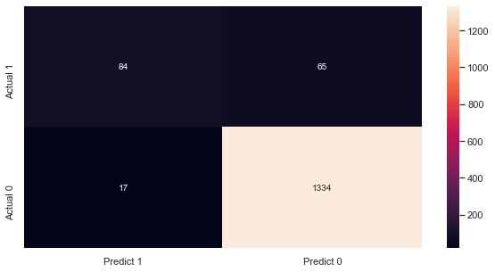

```python
cm = metrics.confusion_matrix(y_test, y_predict, labels = [1,0])

df_cm = pd.DataFrame(cm, index = [i for i in ['Actual 1', 'Actual 0']],
                    columns = [i for i in ['Predict 1', 'Predict 0']])

plt.figure(figsize = (10,5))

sns.heatmap(df_cm, annot= True, fmt = 'g');
```

#### *The confusion matrix Explanation*:

##### True Positives (TP): we correctly predicted them to accept the loan and they accepted: 84

##### True Negatives (TN): we correctly predicted them that they will reject the loan offer and they rejected: 1334

##### False Positives (FP): we incorrectly predicted that they will accept the loan and actually they didn't (a "Type I error") 17 Falsely predict positive Type I error

##### False Negatives (FN): we incorrectly predicted that they will not accept the loan and actually they accepted (a "Type II error") 65 Falsely predict negative Type II error

#### So, here we should be more concern about the FN value that is Type II error, because, there is a chance of missing such valuable customers to the bank, who are ready to accept the loan or who really need a loan. Thus, our aim should be to decrease the value of FN to bring more profit to the institution.

## 5.a.2 Classification Report - Logistic

```python
print(metrics.classification_report(y_test, y_predict))
```

```
              precision    recall  f1-score   support

         0.0       0.95      0.99      0.97      1351
         1.0       0.83      0.56      0.67       149

    accuracy                           0.95      1500
   macro avg       0.89      0.78      0.82      1500
weighted avg       0.94      0.95      0.94      1500
```

## 5.b. Classification model - Naïve Bayes

```python
print(x_train.shape)
print(y_train.shape)
```

```
(3500, 11)
(3500,)
```

```python
print(x_test.shape)
print(y_test.shape)
```

```
(1500, 11)
(1500,)
```

```python
# To model the Gaussian Navie Bayes classifier
from sklearn.naive_bayes import GaussianNB
pl = GaussianNB()
pl_GNB = pl.fit(x_train, y_train.ravel())
```

Now GaussianNB classifier is built. The classifier is trained using training data. We can use fit() method for training it. After building a classifier, our model is ready to make predictions. We can use predict() method with test set features as its parameters.

```python
y_train_pred_GNB = pl.predict(x_train)

# To calculate the accuracy score of the model

from sklearn.metrics import accuracy_score
print("Training Model Accuracy: {0:.4f}".format(metrics.accuracy_score(y_train, y_train_pred_GNB)))
print()
```

```
Training Model Accuracy: 0.8900
```

```python
y_test_pred_GNB = pl.predict(x_test)

# To calculate the accuracy score of the model
from sklearn import metrics
from sklearn.metrics import accuracy_score
print("Testing Model Accuracy: {0:.4f}".format(metrics.accuracy_score(y_test, y_test_pred_GNB)))
```

```
Testing Model Accuracy: 0.8747
```

## 5.b.1. Classification model - Naïve Bayes - Confusion Matrix

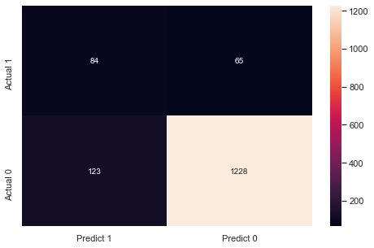

```python
cmGNB = metrics.confusion_matrix(y_test, y_test_pred_GNB, labels = [1,0])

df_cmGNB = pd.DataFrame(cmGNB, index = [i for i in ['Actual 1', 'Actual 0']],
                    columns = [i for i in ['Predict 1', 'Predict 0']])

plt.figure(figsize = (8,5))

sns.heatmap(df_cmGNB, annot= True, fmt = 'g');
```

#### *The confusion matrix Explanation*:

##### True Positives (TP): we correctly predicted them to accept the loan and they accepted: 84

##### True Negatives (TN): we correctly predicted them that they will reject the loan offer and they rejected: 1228

##### False Positives (FP): we incorrectly predicted that they will accept the loan and actually they didn't (a "Type I error") 123 Falsely predict positive Type I error

##### False Negatives (FN): we incorrectly predicted that they will not accept the loan and actually they accepted (a "Type II error") 65 Falsely predict negative Type II error

#### So, here we should be more concern about the FN value that is Type II error, because, there is a chance of missing such valuable customers to the bank, who are ready to accept the loan or who really need a loan. Thus, our aim should be to decrease the value of FN to bring more profit to the institution.

## 5.b.2. Classification Report - Naïve Bayes

```python
print(metrics.classification_report(y_test, y_test_pred_GNB, labels=[1, 0]))
```

```
              precision    recall  f1-score   support

           1       0.41      0.56      0.47       149
           0       0.95      0.91      0.93      1351

    accuracy                           0.87      1500
   macro avg       0.68      0.74      0.70      1500
weighted avg       0.90      0.87      0.88      1500
```

The recall and precision values for ture positive numbers with value 1 are below 70%

## 5.c. Classification model - K-NN

```python
print(x_train.shape)
print(y_train.shape)
```

```
(3500, 11)
(3500,)
```

```python
print(x_test.shape)
print(y_test.shape)
```

```
(1500, 11)
(1500,)
```

Build the model and train and test on training and test sets respectively using scikit-learn. Print the Accuracy of the model with different values of k=3,5,9.

```python
# loading library
from sklearn.neighbors import KNeighborsClassifier
from sklearn.metrics import accuracy_score
from sklearn.metrics import recall_score

# Learning the model (k=3)
knn3 = KNeighborsClassifier(n_neighbors = 3)

# fitting the model
knn_fit3 = knn3.fit(x_train, y_train)

y_train_pred_knn3 = knn_fit3.predict(x_train)

print("Training Model Accuracy for k = 3: {0:.4f}".format(metrics.accuracy_score(y_train, y_train_pred_knn3)))

y_test_pred_knn3 = knn_fit3.predict(x_test)

print("Testing Model Accuracy for k = 3: {0:.4f}".format(metrics.accuracy_score(y_test, y_test_pred_knn3)))

print()

# Learning the model (k=5)
knn5 = KNeighborsClassifier(n_neighbors = 5)

# fitting the model
knn_fit5 = knn5.fit(x_train, y_train)

y_train_pred_knn5 = knn_fit5.predict(x_train)

print("Training Model Accuracy for k = 5: {0:.4f}".format(metrics.accuracy_score(y_train, y_train_pred_knn5)))

y_test_pred_knn5 = knn_fit5.predict(x_test)

print("Testing Model Accuracy for k = 5: {0:.4f}".format(metrics.accuracy_score(y_test, y_test_pred_knn5)))

print()

# Learning the model (k=9)
knn9 = KNeighborsClassifier(n_neighbors = 9)

# fitting the model
knn_fit9 = knn9.fit(x_train, y_train)

y_train_pred_knn9 = knn_fit9.predict(x_train)

print("Training Model Accuracy for k = 9: {0:.4f}".format(metrics.accuracy_score(y_train, y_train_pred_knn9)))

y_test_pred_knn9 = knn_fit9.predict(x_test)

print("Testing Model Accuracy for k = 9: {0:.4f}".format(metrics.accuracy_score(y_test, y_test_pred_knn9)))

print()
```

```
Training Model Accuracy for k = 3: 0.9551
Testing Model Accuracy for k = 3: 0.9040

Training Model Accuracy for k = 5: 0.9360
Testing Model Accuracy for k = 5: 0.9073

Training Model Accuracy for k = 9: 0.9280
Testing Model Accuracy for k = 9: 0.9100
```

```python
# creating odd list of k for KNN
mylist = list(range(1,20))

# substituating just the odd ones
neighbors = list(filter(lambda x: x % 2 != 0, mylist))
```

#### Run the KNN with no of neighbours ranging from 1,3,5..19 and

#### Find the optimal number of neighbours from the above list using the Misclassification error

```python
# creating an empty list to hold accuracy scores
ac_scores = []

# performing accuracy metrics for values from 1,3,5,7,.....19
for k in neighbors:
    knn = KNeighborsClassifier(n_neighbors = k)
    knn.fit(x_train,y_train)
    # predict the response
    y_predKNN = knn.predict(x_test)
    # evaluate accuracy
    scores = accuracy_score(y_test, y_predKNN)
    ac_scores.append(scores)

# Changing to misclassification error
MSE = [1- x for x in ac_scores]

# determining best k
optimal_k = neighbors[MSE.index(min(MSE))]
print("the optimal number of neigbors is %d" % optimal_k)
```

```
the optimal number of neigbors is 9
```

#### - Plot misclassification error vs k (with k value on X-axis) using matplotlib.

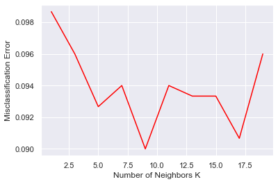

```python
# misclassification error vs k
plt.plot(neighbors, MSE, color = 'red')
plt.xlabel('Number of Neighbors K')
plt.ylabel('Misclassification Error')
plt.show()
```

#### - Hence, the misclassification error is minimum at a k value of 9

```python
# using k = 9 for the final model for prediction
knn = KNeighborsClassifier(n_neighbors = 9)

# fitting the model
knn_fit = knn.fit(x_train, y_train)

y_train_pred_knn = knn_fit.predict(x_train)

print("Training Model Accuracy value for k = 9: {0:.4f}".format(metrics.accuracy_score(y_train,y_train_pred_knn )))


print("Training Model recall value for k = 9: {0:.4f}".format(metrics.recall_score(y_train, y_train_pred_knn)))
print()

y_test_pred_knn = knn_fit.predict(x_test)
print("Testing Model Accuracy value for k = 9: {0:.4f}".format(metrics.accuracy_score(y_test, y_test_pred_knn)))
print("Testing Model recall value for k = 9: {0:.4f}".format(metrics.recall_score(y_test, y_test_pred_knn)))
```

```
Training Model Accuracy value for k = 9: 0.9280
Training Model recall value for k = 9: 0.4079

Testing Model Accuracy value for k = 9: 0.9100
Testing Model recall value for k = 9: 0.3356
```

## 5.c.1. Classification model - K-NN - Confusion Matrix

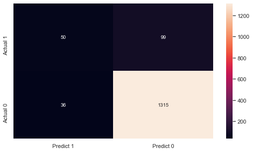

```python
cmKNN = metrics.confusion_matrix(y_test, y_test_pred_knn, labels = [1,0])

df_cmKNN = pd.DataFrame(cmKNN, index = [i for i in ['Actual 1', 'Actual 0']],
                    columns = [i for i in ['Predict 1', 'Predict 0']])

plt.figure(figsize = (9,5))
sns.heatmap(df_cmKNN, annot= True, fmt = 'g');
```

#### *The confusion matrix Explanation*:

##### True Positives (TP): we correctly predicted them to accept the loan and they accepted: 50

##### True Negatives (TN): we correctly predicted them that they will reject the loan offer and they rejected: 1315

##### False Positives (FP): we incorrectly predicted that they will accept the loan and actually they didn't (a "Type I error") 36 Falsely predict positive Type I error

##### False Negatives (FN): we incorrectly predicted that they will not accept the loan and actually they accepted (a "Type II error") 99 Falsely predict negative Type II error

#### So, here we should be more concern about the FN value that is Type II error, because, there is a chance of missing such valuable customers to the bank, who are ready to accept the loan or who really need a loan. Thus, our aim should be to decrease the value of FN to bring more profit to the institution.

## 5.c.2. Classification Report - K-NN

```python
print(metrics.classification_report(y_test, y_test_pred_knn, labels = [0,1]))
```

```
              precision    recall  f1-score   support

           0       0.93      0.97      0.95      1351
           1       0.58      0.34      0.43       149

    accuracy                           0.91      1500
   macro avg       0.76      0.65      0.69      1500
weighted avg       0.90      0.91      0.90      1500
```

## 6. Comments On the Best Model and basis of selecting the model as Best one

#### 9. Due to very high accuracy value and F1 score, the Logistic regression model is the best model to be chosen to predict the likelihood of a customer buying a personal loan. Hence, it is advisable to opt for Logistic regression model for production.

#### 10. Since our target is to minimize the FN value or type II error to give more profit to bank, therefore it is clearly not advisable to go for KNN model rather Logistic Regression model or Naive Bayes model can be of choice model, preferably the Logistic Regression due to its comparative high value of Accuracy and F1 score.

#### 11.Here a huge multi collinearity has been observed between the column Age and Experience. Consequently, this multi collinearity may weaken the statistical power of regression model and affects the precision of model adversely, thus to avoid this and to enhance the precision value any one of the said columns can be omitted while building of model. While doing so it is necessary to check the swing of target column due to inclusion or exclusion of these highly collinear attributes.

## 7. Use of Minmax Scalar and VIF to re evaluate the model

```python
# train-test-split
df_train, df_test=train_test_split(df,train_size=0.7,random_state=100)
print(df_train.shape)
df_test.shape
```

```
(3500, 14)
```

```
(1500, 14)
```

```python
# 1. Create and object or Instantiate an object
from sklearn.preprocessing import MinMaxScaler
scaler=MinMaxScaler()

#create list of numerica variables only
num_vars=['ID', 'ZIP Code', 'Age', 'Experience', 'Income', 'PL','Family', 'CCAvg', 'Education', 'Mortgage', 'Securities_Account', 'CD_Account', 'Online', 'CreditCard' ]

#2. Fit and transform the data
df_train[num_vars]=scaler.fit_transform(df_train[num_vars])
print(df_train.head(2))
print()
#2. Fit and transform the data
df_test[num_vars]=scaler.fit_transform(df_test[num_vars])
print(df_test.head(2))
```

```
            ID       Age  Experience    Income  ZIP Code  Family  CCAvg  \
4966  0.993397  0.409091    0.434783  0.120370  0.204033     0.0   0.07
4086  0.817327  0.613636    0.630435  0.013889  0.466596     1.0   0.02

      Education  Mortgage   PL  Securities_Account  CD_Account  Online  \
4966        0.0  0.225197  0.0                 0.0         0.0     0.0
4086        0.0  0.000000  0.0                 1.0         0.0     0.0

      CreditCard
4966         0.0
4086         0.0

            ID       Age  Experience    Income  ZIP Code  Family  CCAvg  \
789   0.157863  0.136364    0.111111  0.109524  0.948193     1.0   0.03
2507  0.501601  0.818182    0.800000  0.247619  0.924402     1.0   0.21

      Education  Mortgage   PL  Securities_Account  CD_Account  Online  \
789         0.5  0.000000  0.0                 0.0         0.0     1.0
2507        0.0  0.382353  0.0                 0.0         0.0     1.0

      CreditCard
789          0.0
2507         1.0
```

```python
# correlation of entire dataframe
corr_matrix = df_train.corr()
# features more realted to Personal Loan
corr_matrix['PL'].sort_values(ascending=False)
```

```
PL                    1.000000
Income                0.499455
CCAvg                 0.360803
CD_Account            0.302732
Education             0.147855
Mortgage              0.109041
Family                0.049555
Securities_Account    0.029233
ZIP Code              0.009083
Age                   0.002832
Experience            0.001829
CreditCard           -0.001294
Online               -0.010157
ID                   -0.022173
Name: PL, dtype: float64
```

#### checked the correlation of Personal Loan with all other variables

```python
# deviding into X and y feature
# X and y train
y_train1=df_train.pop('PL')
x_train1=df_train

x_train1.columns
```

```
Index(['ID', 'Age', 'Experience', 'Income', 'ZIP Code', 'Family', 'CCAvg',
       'Education', 'Mortgage', 'Securities_Account', 'CD_Account', 'Online',
       'CreditCard'],
      dtype='object')
```

```python
y_train1
```

```
4966    0.0
4086    0.0
2881    0.0
1237    1.0
1429    0.0
       ...
4149    0.0
1890    0.0
350     0.0
79      0.0
3927    0.0
Name: PL, Length: 3500, dtype: float64
```

```python
x_train1.drop(['ID', 'ZIP Code'], axis =1, inplace = True)
x_train1.columns
```

```
Index(['Age', 'Experience', 'Income', 'Family', 'CCAvg', 'Education',
       'Mortgage', 'Securities_Account', 'CD_Account', 'Online', 'CreditCard'],
      dtype='object')
```

```python
y_test1 = df_test.pop('PL')
x_test1 = df_test
x_test1.columns
```

```
Index(['ID', 'Age', 'Experience', 'Income', 'ZIP Code', 'Family', 'CCAvg',
       'Education', 'Mortgage', 'Securities_Account', 'CD_Account', 'Online',
       'CreditCard'],
      dtype='object')
```

```python
y_test1
```

```
789     0.0
2507    0.0
2376    0.0
1378    0.0
598     0.0
       ...
4276    0.0
1528    0.0
4259    1.0
3686    0.0
1372    1.0
Name: PL, Length: 1500, dtype: float64
```

```python
x_test1.drop(['ID', 'ZIP Code'], axis =1, inplace = True)
x_test1.columns
```

```
Index(['Age', 'Experience', 'Income', 'Family', 'CCAvg', 'Education',
       'Mortgage', 'Securities_Account', 'CD_Account', 'Online', 'CreditCard'],
      dtype='object')
```

## Logistic Regression

```python
#Fit the model on train
model1 = LogisticRegression(solver = 'liblinear')
model1.fit(x_train1, y_train1)

#predict on test
y_predict1 = model1.predict(x_test1)
```

```python
model_score1 = model1.score(x_test1, y_test1)
print(model_score1)
model_score1_train = model1.score(x_train1, y_train1)
print(model_score1_train)
```

```
0.944
0.9511428571428572
```

```python
logit1 = sm.Logit(y_train1, sm.add_constant(x_train1))
lg = logit1.fit()
lg.summary()
```

```
Optimization terminated successfully.
         Current function value: 0.121703
         Iterations 9
```

Logit Regression Results

| Dep. Variable: | PL | No. Observations: | 3500 |
| --- | --- | --- | --- |
| Model: | Logit | Df Residuals: | 3488 |
| Method: | MLE | Df Model: | 11 |
| Date: | Sat, 27 Jun 2020 | Pseudo R-squ.: | 0.6038 |
| Time: | 00:02:32 | Log-Likelihood: | -425.96 |
| converged: | True | LL-Null: | -1075.0 |
| Covariance Type: | nonrobust | LLR p-value: | 1.169e-271 |

|  | coef | std err | z | P>\|z\| | [0.025 | 0.975] |
| --- | --- | --- | --- | --- | --- | --- |
| const | -11.4112 | 0.612 | -18.652 | 0.000 | -12.610 | -10.212 |
| Age | -2.0175 | 3.207 | -0.629 | 0.529 | -8.304 | 4.269 |
| Experience | 2.9913 | 3.332 | 0.898 | 0.369 | -3.540 | 9.523 |
| Income | 12.3970 | 0.705 | 17.588 | 0.000 | 11.015 | 13.778 |
| Family | 2.0949 | 0.273 | 7.681 | 0.000 | 1.560 | 2.630 |
| CCAvg | 1.2012 | 0.485 | 2.478 | 0.013 | 0.251 | 2.151 |
| Education | 3.7623 | 0.288 | 13.046 | 0.000 | 3.197 | 4.328 |
| Mortgage | 0.4866 | 0.437 | 1.114 | 0.265 | -0.369 | 1.342 |
| Securities_Account | -0.5995 | 0.330 | -1.818 | 0.069 | -1.246 | 0.047 |
| CD_Account | 3.4901 | 0.383 | 9.113 | 0.000 | 2.739 | 4.241 |
| Online | -0.9644 | 0.195 | -4.941 | 0.000 | -1.347 | -0.582 |
| CreditCard | -0.9188 | 0.241 | -3.819 | 0.000 | -1.390 | -0.447 |

```python
#ways of dropping variables:
#significance of variables (p-values)
#VIF--variance inflation factor

#Computing VIF
#VIF=1/1-r^2
#create a dataframe which will contain all the features and their respective VIF values
import statsmodels.api as sm
from statsmodels.stats.outliers_influence import variance_inflation_factor

vif=pd.DataFrame()
vif['Features'] = x_train1.columns
vif['VIF'] = [variance_inflation_factor(x_train1.values,i) for i in range(x_train1.shape[1]) ]
vif['VIF'] = round(vif['VIF'],2)
vif = vif.sort_values(by = 'VIF', ascending = False)
vif
```

|  | Features | VIF |
| --- | --- | --- |
| 1 | Experience | 429.35 |
| 0 | Age | 420.46 |
| 2 | Income | 5.08 |
| 4 | CCAvg | 3.83 |
| 9 | Online | 2.33 |
| 3 | Family | 2.18 |
| 5 | Education | 1.98 |
| 10 | CreditCard | 1.49 |
| 6 | Mortgage | 1.35 |
| 8 | CD_Account | 1.34 |
| 7 | Securities_Account | 1.24 |

Assumption:

```
a) A VIF value of 1 indicates there is no relationship / correlation between independent variables and any others.

b) A VIF value between 1 to 5 shows a moderate correlation but not severe enough to warrant corrective measures.

c) A VIF value greater than 5 shows critical levels of multicollinearity and the p value to be checked for.
```

Thus, Here, we will remove the one by one which are having VIF>5 and p > 0.05

```python
x_train1 = x_train1.drop(['Experience'], axis =1)
logit1 = sm.Logit(y_train1, sm.add_constant(x_train1))
lg = logit1.fit()
lg.summary()
```

```
Optimization terminated successfully.
         Current function value: 0.121821
         Iterations 9
```

Logit Regression Results

| Dep. Variable: | PL | No. Observations: | 3500 |
| --- | --- | --- | --- |
| Model: | Logit | Df Residuals: | 3489 |
| Method: | MLE | Df Model: | 10 |
| Date: | Sat, 27 Jun 2020 | Pseudo R-squ.: | 0.6034 |
| Time: | 00:02:35 | Log-Likelihood: | -426.37 |
| converged: | True | LL-Null: | -1075.0 |
| Covariance Type: | nonrobust | LLR p-value: | 1.507e-272 |

|  | coef | std err | z | P>\|z\| | [0.025 | 0.975] |
| --- | --- | --- | --- | --- | --- | --- |
| const | -11.3557 | 0.609 | -18.659 | 0.000 | -12.549 | -10.163 |
| Age | 0.8441 | 0.351 | 2.401 | 0.016 | 0.155 | 1.533 |
| Income | 12.4173 | 0.704 | 17.632 | 0.000 | 11.037 | 13.798 |
| Family | 2.0931 | 0.273 | 7.672 | 0.000 | 1.558 | 2.628 |
| CCAvg | 1.1961 | 0.485 | 2.468 | 0.014 | 0.246 | 2.146 |
| Education | 3.7180 | 0.284 | 13.098 | 0.000 | 3.162 | 4.274 |
| Mortgage | 0.4725 | 0.436 | 1.085 | 0.278 | -0.381 | 1.326 |
| Securities_Account | -0.5967 | 0.329 | -1.814 | 0.070 | -1.242 | 0.048 |
| CD_Account | 3.4961 | 0.382 | 9.146 | 0.000 | 2.747 | 4.245 |
| Online | -0.9566 | 0.195 | -4.911 | 0.000 | -1.338 | -0.575 |
| CreditCard | -0.9126 | 0.240 | -3.796 | 0.000 | -1.384 | -0.441 |

```python
vif=pd.DataFrame()
vif['Features'] = x_train1.columns
vif['VIF'] = [variance_inflation_factor(x_train1.values,i) for i in range(x_train1.shape[1]) ]
vif['VIF'] = round(vif['VIF'],2)
vif = vif.sort_values(by = 'VIF', ascending = False)
vif
```

|  | Features | VIF |
| --- | --- | --- |
| 1 | Income | 4.99 |
| 3 | CCAvg | 3.83 |
| 0 | Age | 3.38 |
| 8 | Online | 2.31 |
| 2 | Family | 2.16 |
| 4 | Education | 1.92 |
| 9 | CreditCard | 1.49 |
| 5 | Mortgage | 1.35 |
| 7 | CD_Account | 1.34 |
| 6 | Securities_Account | 1.24 |

```python
x_test1 = x_test1.drop(['Experience'], axis =1)
#Fit the model on train
model2 = LogisticRegression(solver = 'liblinear')
model2.fit(x_train1, y_train1)

#predict on test
y_predict1 = model2.predict(x_test1)
```

```python
model_score2 = model2.score(x_test1, y_test1)
print(model_score2)
model_score2_train = model2.score(x_train1, y_train1)
print(model_score2_train)
```

```
0.944
0.9508571428571428
```

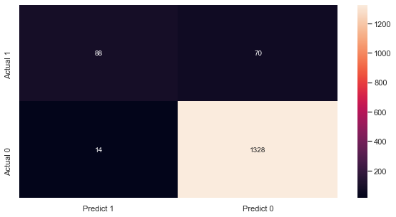

```python
cm_VIF = metrics.confusion_matrix(y_test1, y_predict1, labels = [1,0])

df_cm_VIF = pd.DataFrame(cm_VIF, index = [i for i in ['Actual 1', 'Actual 0']],
                    columns = [i for i in ['Predict 1', 'Predict 0']])

plt.figure(figsize = (10,5))
sns.heatmap(df_cm_VIF, annot= True, fmt = 'g')
```

#### *The confusion matrix Explanation*:

##### True Positives (TP): we correctly predicted them to accept the loan and they accepted: 88

##### True Negatives (TN): we correctly predicted them that they will reject the loan offer and they rejected: 1328

##### False Positives (FP): we incorrectly predicted that they will accept the loan and actually they didn't (a "Type I error") 14 Falsely predict positive Type I error

##### False Negatives (FN): we incorrectly predicted that they will not accept the loan and actually they accepted (a "Type II error") 70 Falsely predict negative Type II error

#### So, here we should be more concern about the FN value that is Type II error, because, there is a chance of missing such valuable customers to the bank, who are ready to accept the loan or who really need a loan. Thus, our aim should be to decrease the value of FN to bring more profit to the institution.

```python
print(metrics.classification_report(y_test1, y_predict1, labels = [0,1]))
```

```
              precision    recall  f1-score   support

           0       0.95      0.99      0.97      1342
           1       0.86      0.56      0.68       158

    accuracy                           0.94      1500
   macro avg       0.91      0.77      0.82      1500
weighted avg       0.94      0.94      0.94      1500
```

#### - It has an accuracy of 0.94 and f1 score of 0.68, which are almost same to the model built without using minmax scalar and VIF.

## Naive Baye's

```python
clf = GaussianNB()
clf.fit(x_train1, y_train1)
y_predGNB1 = clf.predict(x_test1)
accuracy_score(y_test1, y_predGNB1, normalize = True)
```

```
0.8806666666666667
```

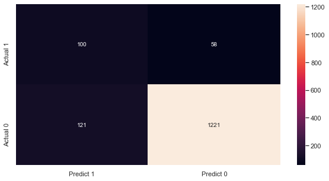

```python
cmGNB_VIF = metrics.confusion_matrix(y_test1, y_predGNB1, labels = [1,0])

df_cmGNB_VIF = pd.DataFrame(cmGNB_VIF, index = [i for i in ['Actual 1', 'Actual 0']],
                    columns = [i for i in ['Predict 1', 'Predict 0']])

plt.figure(figsize = (10,5))
sns.heatmap(df_cmGNB_VIF, annot= True, fmt = 'g')
```

#### *The confusion matrix Explanation*:

##### True Positives (TP): we correctly predicted them to accept the loan and they accepted: 100

##### True Negatives (TN): we correctly predicted them that they will reject the loan offer and they rejected: 1221

##### False Positives (FP): we incorrectly predicted that they will accept the loan and actually they didn't (a "Type I error") 121 Falsely predict positive Type I error

##### False Negatives (FN): we incorrectly predicted that they will not accept the loan and actually they accepted (a "Type II error") 58 Falsely predict negative Type II error

#### So, here we should be more concern about the FN value that is Type II error, because, there is a chance of missing such valuable customers to the bank, who are ready to accept the loan or who really need a loan. Thus, our aim should be to decrease the value of FN to bring more profit to the institution.

```python
print(metrics.classification_report(y_test1, y_predGNB1, labels = [0,1]))
```

```
              precision    recall  f1-score   support

           0       0.95      0.91      0.93      1342
           1       0.45      0.63      0.53       158

    accuracy                           0.88      1500
   macro avg       0.70      0.77      0.73      1500
weighted avg       0.90      0.88      0.89      1500
```

#### It has an accuracy of 0.88 and f1-score of 0.53, which is infact better than the Naive Baye's model built without using minmax scalar and VIF

## KNN

```python
from sklearn.neighbors import KNeighborsClassifier
knn = KNeighborsClassifier(n_neighbors = 9)
knn_fit1 = knn.fit(x_train1, y_train1)

y_train_pred_knn1 = knn_fit1.predict(x_train1)

print("Training Model Accuracy value for k = 9: {0:.4f}".format(metrics.accuracy_score(y_train1,y_train_pred_knn1 )))


print("Training Model recall value for k = 9: {0:.4f}".format(metrics.recall_score(y_train1, y_train_pred_knn1)))
print()

y_test_pred_knn1 = knn_fit1.predict(x_test1)
print("Testing Model Accuracy value for k = 9: {0:.4f}".format(metrics.accuracy_score(y_test1, y_test_pred_knn1)))
print("Testing Model recall value for k = 9: {0:.4f}".format(metrics.recall_score(y_test1, y_test_pred_knn1)))
```

```
Training Model Accuracy value for k = 9: 0.9571
Training Model recall value for k = 9: 0.5497

Testing Model Accuracy value for k = 9: 0.9513
Testing Model recall value for k = 9: 0.5633
```

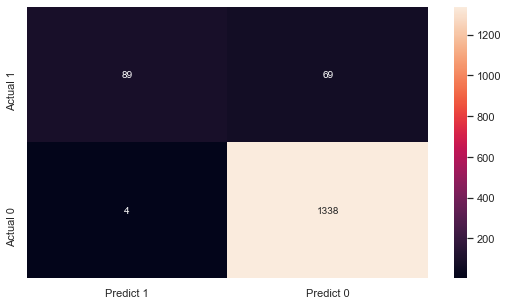

```python
cmKNN_VIF = metrics.confusion_matrix(y_test1, y_test_pred_knn1, labels = [1,0])

df_cmKNN_VIF = pd.DataFrame(cmKNN_VIF, index = [i for i in ['Actual 1', 'Actual 0']],
                    columns = [i for i in ['Predict 1', 'Predict 0']])

plt.figure(figsize = (9,5))
sns.heatmap(df_cmKNN_VIF, annot= True, fmt = 'g');
```

#### *The confusion matrix Explanation*:

##### True Positives (TP): we correctly predicted them to accept the loan and they accepted: 89

##### True Negatives (TN): we correctly predicted them that they will reject the loan offer and they rejected: 1338

##### False Positives (FP): we incorrectly predicted that they will accept the loan and actually they didn't (a "Type I error") 4 Falsely predict positive Type I error

##### False Negatives (FN): we incorrectly predicted that they will not accept the loan and actually they accepted (a "Type II error") 69 Falsely predict negative Type II error

#### So, here we should be more concern about the FN value that is Type II error, because, there is a chance of missing such valuable customers to the bank, who are ready to accept the loan or who really need a loan. Thus, our aim should be to decrease the value of FN to bring more profit to the institution.

```python
print(metrics.classification_report(y_test1, y_test_pred_knn1, labels = [0,1]))
```

```
              precision    recall  f1-score   support

           0       0.95      1.00      0.97      1342
           1       0.96      0.56      0.71       158

    accuracy                           0.95      1500
   macro avg       0.95      0.78      0.84      1500
weighted avg       0.95      0.95      0.95      1500
```

#### Here the accuracy is 0.95 and f1-score is 0.71 which is far better than the KNN model built without using minmax scalar and VIF.

## 8. Comments after use of VIF and minmax scalar

#### Accuracy value of Logistic = 0.94

#### Accuracy value of Naïve Baye’s = 0.88

#### Accuracy value of KNN = 0.95

#### f1 - score of Logistic = 0.68

#### f1 - score of Naïve Baye’s = 0.53

#### f1 - score of KNN = 0.71

### 1.Thus, in terms of accuracy, 0.95 >0.94 >0.88, i.e. KNN Accuracy > Logistic Accuracy > Naïve Baye’s Accuracy

### 2. In terms of f1-score, 0.71 >0.68 >0.53, i.e. KKN f1-score > Logistic f1-score > Naïve Baye’s f1-score

### 3. Hence, from the above comparison, it can be clearly understood that, the KNN model is the best model to predict the likelihood of a liability customer buying personal loan.

## 7. Optional

## Classification model using SVM

```python
from sklearn.svm import SVC

# Building a support vector Machine on train data
svc_model = SVC(C= 0.1, kernel = 'linear', gamma = 1)
svc_fit = svc_model.fit(x_train, y_train)

y_train_pred_svc = svc_fit.predict(x_train)

print("Training Model Accuracy value : {0:.4f}".format(accuracy_score(y_train,y_train_pred_svc )))

y_test_pred_svc = svc_fit.predict(x_test)
print("Testing Model Accuracy value: {0:.4f}".format(accuracy_score(y_test, y_test_pred_svc)))
```

```
Training Model Accuracy value : 0.9543
Testing Model Accuracy value: 0.9493
```

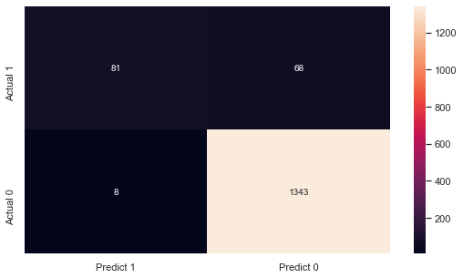

```python
cmSVC = metrics.confusion_matrix(y_test, y_test_pred_svc, labels = [1,0])

df_cmSVC = pd.DataFrame(cmSVC, index = [i for i in ['Actual 1', 'Actual 0']],
                    columns = [i for i in ['Predict 1', 'Predict 0']])

plt.figure(figsize = (9,5))
sns.heatmap(df_cmSVC, annot= True, fmt = 'g');
```

#### *The confusion matrix Explanation:

##### True Positives (TP): we correctly predicted them to accept the loan and they accepted: 81

##### True Negatives (TN): we correctly predicted them that they will reject the loan offer and they rejected: 1343

##### False Positives (FP): we incorrectly predicted that they will accept the loan and actually they didn't (a "Type I error") 8 Falsely predict positive Type I error

##### False Negatives (FN): we incorrectly predicted that they will not accept the loan and actually they accepted (a "Type II error") 68 Falsely predict negative Type II error

#### So, here we should be more concern about the FN value that is Type II error, because, there is a chance of missing such valuable customers to the bank, who are ready to accept the loan or who really need a loan. Thus, our aim should be to decrease the value of FN to bring more profit to the institution.

```python
print(metrics.classification_report(y_test, y_test_pred_svc, labels = [0,1]))
```

```
              precision    recall  f1-score   support

           0       0.95      0.99      0.97      1351
           1       0.91      0.54      0.68       149

    accuracy                           0.95      1500
   macro avg       0.93      0.77      0.83      1500
weighted avg       0.95      0.95      0.94      1500
```

### Comments:

#### - The F1 score and accuracy of the model are 0.68 and 0.95 respectively.

#### - In-addition, the FN value or type II error is a bit more than Logistic regression and Naive bayes.

#### - Thus, it is advisable to opt for KNN Model with using VIF & minmaxscalar or Logistic regression without using VIF & min max scalar model for production.